# STAT 306 Project - Exporing variables that affect housing price

by Group D3 - Tianne Lee, Lisanne Huijs, Kai Duan, Jeff Huang

## Introduction

Housing prices is a widely discussed topic, present and past. Moreover, the topic of housing prices is relevant to everyone.

This project aims to investigate the relationship between the median house price among other variables. We would like to see which factors contribute to housing prices the most. Such study will help us understand and be more familiar with the housing market, helping us prepare for future investments.

### Data source

The dataset is a modified version of the California Housing dataset based on the 1990 US census data, from the textbook Hands-On Machine Learning notebooks by Aurélien Géron. The CSV file of the data is linked [here](https://github.com/ageron/handson-ml/blob/master/datasets/housing/housing.csv).

This dataset is about houses found in given California block groups (districts) based on the 1990 census data. Each observation in the dataset corresponds to a district.

## Analysis

We will start our analysis step by loading a few R libraries and the dataset.

```r
library(tidyverse)
library(leaps)
library(broom)
library(ggcorrplot)
library(car)
library(cowplot)
```

[output not shown]

```r
house <- read.csv("https://raw.githubusercontent.com/ageron/handson-ml/master/datasets/housing/housing.csv")
house <- house %>% drop_na()
head(house)
```

A data.frame: 6 × 10

|  | longitude <dbl> | latitude <dbl> | housing_median_age <dbl> | total_rooms <dbl> | total_bedrooms <dbl> | population <dbl> | households <dbl> | median_income <dbl> | median_house_value <dbl> | ocean_proximity <chr> |
| --- | --- | --- | --- | --- | --- | --- | --- | --- | --- | --- |
| 1 | -122.23 | 37.88 | 41 | 880 | 129 | 322 | 126 | 8.3252 | 452600 | NEAR BAY |
| 2 | -122.22 | 37.86 | 21 | 7099 | 1106 | 2401 | 1138 | 8.3014 | 358500 | NEAR BAY |
| 3 | -122.24 | 37.85 | 52 | 1467 | 190 | 496 | 177 | 7.2574 | 352100 | NEAR BAY |
| 4 | -122.25 | 37.85 | 52 | 1274 | 235 | 558 | 219 | 5.6431 | 341300 | NEAR BAY |
| 5 | -122.25 | 37.85 | 52 | 1627 | 280 | 565 | 259 | 3.8462 | 342200 | NEAR BAY |
| 6 | -122.25 | 37.85 | 52 | 919 | 213 | 413 | 193 | 4.0368 | 269700 | NEAR BAY |

### Data preprocessing

The variable `median_house_value` is our response variable. In order to explore the relationships more clearly, we would do some data cleaning prior carrying out linear modelling.

We observe that the dataset uses a lot of "total" counts in a district, for example, `total_rooms` and `total_bedrooms`. We think it would be reasonable to convert the total count to mean values by dividing the values with the number of households in the district.

```r
house <- house %>% mutate(rooms_per_household = total_rooms/households,
                       bedrooms_per_household = total_bedrooms/households,
                       population_per_household = population/households)

head(house)
```

A data.frame: 6 × 13

|  | longitude <dbl> | latitude <dbl> | housing_median_age <dbl> | total_rooms <dbl> | total_bedrooms <dbl> | population <dbl> | households <dbl> | median_income <dbl> | median_house_value <dbl> | ocean_proximity <chr> | rooms_per_household <dbl> | bedrooms_per_household <dbl> | population_per_household <dbl> |
| --- | --- | --- | --- | --- | --- | --- | --- | --- | --- | --- | --- | --- | --- |
| 1 | -122.23 | 37.88 | 41 | 880 | 129 | 322 | 126 | 8.3252 | 452600 | NEAR BAY | 6.984127 | 1.0238095 | 2.555556 |
| 2 | -122.22 | 37.86 | 21 | 7099 | 1106 | 2401 | 1138 | 8.3014 | 358500 | NEAR BAY | 6.238137 | 0.9718805 | 2.109842 |
| 3 | -122.24 | 37.85 | 52 | 1467 | 190 | 496 | 177 | 7.2574 | 352100 | NEAR BAY | 8.288136 | 1.0734463 | 2.802260 |
| 4 | -122.25 | 37.85 | 52 | 1274 | 235 | 558 | 219 | 5.6431 | 341300 | NEAR BAY | 5.817352 | 1.0730594 | 2.547945 |
| 5 | -122.25 | 37.85 | 52 | 1627 | 280 | 565 | 259 | 3.8462 | 342200 | NEAR BAY | 6.281853 | 1.0810811 | 2.181467 |
| 6 | -122.25 | 37.85 | 52 | 919 | 213 | 413 | 193 | 4.0368 | 269700 | NEAR BAY | 4.761658 | 1.1036269 | 2.139896 |

Before building a model, we would like to check for any multicolinearity and drop columns with high correlations. To do so, we will fit a full linear model on all of the variables and check the VIF values.

```r
full_model <- lm(median_house_value~., data = house)
tidy(full_model) %>% mutate_if(is.numeric, round, digits=2)
vif(full_model)
```

A tibble: 16 × 5

| term <chr> | estimate <dbl> | std.error <dbl> | statistic <dbl> | p.value <dbl> |
| --- | --- | --- | --- | --- |
| (Intercept) | -2355681.52 | 88612.37 | -26.58 | 0.00 |
| longitude | -27663.39 | 1026.36 | -26.95 | 0.00 |
| latitude | -26352.91 | 1014.10 | -25.99 | 0.00 |
| housing_median_age | 1073.46 | 43.80 | 24.51 | 0.00 |
| total_rooms | -3.59 | 0.94 | -3.84 | 0.00 |
| total_bedrooms | 59.47 | 7.89 | 7.54 | 0.00 |
| population | -38.88 | 1.11 | -35.10 | 0.00 |
| households | 82.75 | 8.31 | 9.96 | 0.00 |
| median_income | 40338.97 | 412.88 | 97.70 | 0.00 |
| ocean_proximityINLAND | -37399.14 | 1752.56 | -21.34 | 0.00 |
| ocean_proximityISLAND | 148227.83 | 30665.57 | 4.83 | 0.00 |
| ocean_proximityNEAR BAY | -4045.56 | 1908.31 | -2.12 | 0.03 |
| ocean_proximityNEAR OCEAN | 3976.53 | 1566.47 | 2.54 | 0.01 |
| rooms_per_household | -3326.76 | 678.19 | -4.91 | 0.00 |
| bedrooms_per_household | 25673.12 | 3233.87 | 7.94 | 0.00 |
| population_per_household | 64.50 | 47.37 | 1.36 | 0.17 |

A matrix: 12 × 3 of type dbl

|  | GVIF | Df | GVIF^(1/(2*Df)) |
| --- | --- | --- | --- |
| longitude | 18.427132 | 1 | 4.292684 |
| latitude | 20.452759 | 1 | 4.522473 |
| housing_median_age | 1.325266 | 1 | 1.151202 |
| total_rooms | 18.222064 | 1 | 4.268731 |
| total_bedrooms | 48.179240 | 1 | 6.941127 |
| population | 6.864198 | 1 | 2.619961 |
| households | 43.989398 | 1 | 6.632450 |
| median_income | 2.679626 | 1 | 1.636956 |
| ocean_proximity | 4.173184 | 4 | 1.195524 |
| rooms_per_household | 12.356066 | 1 | 3.515120 |
| bedrooms_per_household | 10.329821 | 1 | 3.214004 |
| population_per_household | 1.065225 | 1 | 1.032097 |

As seen in the table, multiple variables have a very high GVIF values. We will drop them.

```r
house <- house %>% select(-longitude, -latitude, -total_rooms, -total_bedrooms, -households, -rooms_per_household)
full_2 <- lm(median_house_value~., data = house)
tidy(full_2) %>% mutate_if(is.numeric, round, digits=2)
vif(full_2)
```

A tibble: 10 × 5

| term <chr> | estimate <dbl> | std.error <dbl> | statistic <dbl> | p.value <dbl> |
| --- | --- | --- | --- | --- |
| (Intercept) | 39064.14 | 2750.75 | 14.20 | 0.00 |
| housing_median_age | 978.73 | 45.97 | 21.29 | 0.00 |
| population | 0.60 | 0.48 | 1.24 | 0.21 |
| median_income | 38382.88 | 283.36 | 135.46 | 0.00 |
| ocean_proximityINLAND | -72469.19 | 1266.04 | -57.24 | 0.00 |
| ocean_proximityISLAND | 180019.08 | 32690.26 | 5.51 | 0.00 |
| ocean_proximityNEAR BAY | 12828.94 | 1754.33 | 7.31 | 0.00 |
| ocean_proximityNEAR OCEAN | 17183.97 | 1622.43 | 10.59 | 0.00 |
| bedrooms_per_household | 9831.25 | 1089.15 | 9.03 | 0.00 |
| population_per_household | -352.84 | 49.16 | -7.18 | 0.00 |

A matrix: 6 × 3 of type dbl

|  | GVIF | Df | GVIF^(1/(2*Df)) |
| --- | --- | --- | --- |
| housing_median_age | 1.282730 | 1 | 1.132577 |
| population | 1.128894 | 1 | 1.062494 |
| median_income | 1.108918 | 1 | 1.053052 |
| ocean_proximity | 1.233814 | 4 | 1.026612 |
| bedrooms_per_household | 1.029492 | 1 | 1.014639 |
| population_per_household | 1.008252 | 1 | 1.004118 |

With all GVIF values < 10, we are now ready to visualize the data.

### Visual analysis

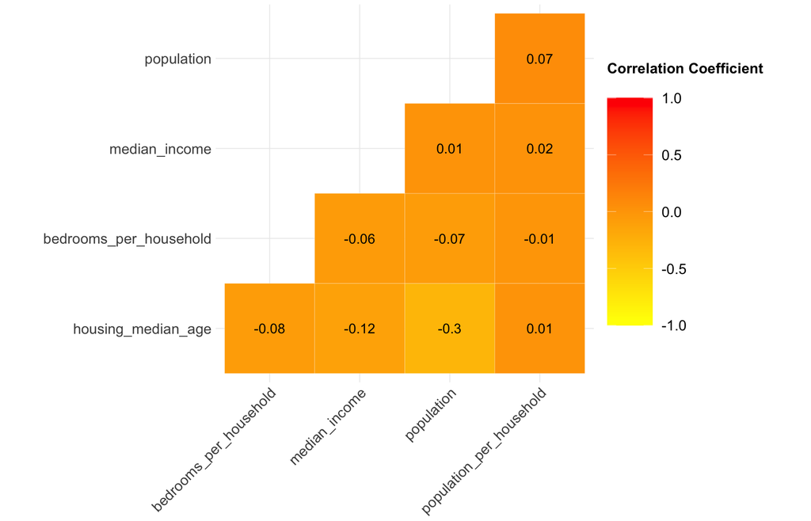

```r
options(repr.plot.width = 14, repr.plot.height = 9)

corr_plot <-
    house |>
    select(-c(ocean_proximity, median_house_value)) |>
    cor() |>
    round(2) |>
    ggcorrplot(hc.order = TRUE,
               outline.col = "white",
               type = "lower",
               lab = TRUE,
               lab_size = 6,
               tl.cex = 18,
               colors = c("yellow", "orange", "red"),
               legend.title = "Correlation Coefficient\n") +
    theme(legend.title = element_text(size = 18, face = "bold"),
          legend.text = element_text(size = 18),
          legend.key.size = unit(2, "cm"))

corr_plot
```

After our preprocessing, we can see that all remaining variables now have low correlation.

Next, we will use a histogram to explore our response variable, `median_house_value`.

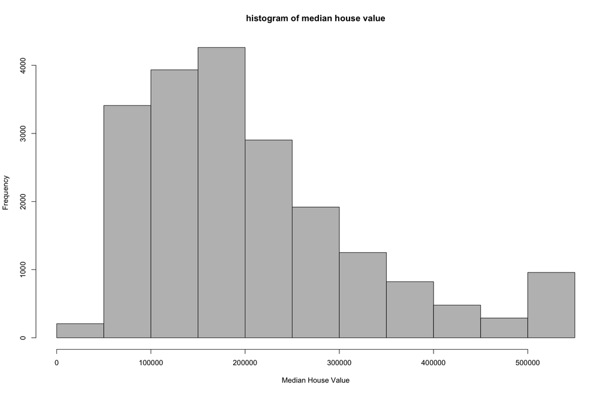

```r
options(scipen = 10000)
hist(house$median_house_value, xlab = "Median House Value", main = "histogram of median house value",col =c("grey"))
```

In this histogram we can see that the response variable is not normally distributed. The data seems to be right skewed.

At last, we will create a bar plot to explore our categorical variable, `ocean_proximity`.

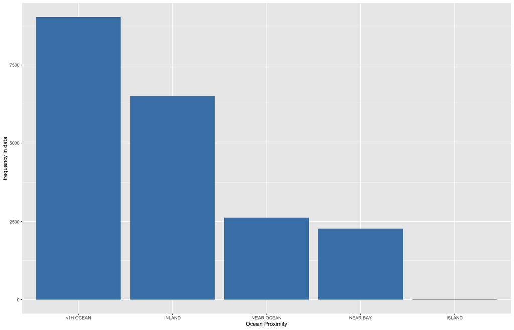

```r
ggplot(house, aes(x=reorder(ocean_proximity, ocean_proximity, function(x)-length(x)))) +
  geom_bar(fill='steelblue') +
  labs(x='Ocean Proximity', y='frequency in data')
```

In this bar plot, we can see that most observations are <1H ocean. There are only 5 observations which are Island.

### The full model

where

- $x_1$ = `longitude`
- $x_2$ = `latitude`
- $x_3$ = `housing_median_age`
- $x_4$ = `total_rooms`
- $x_5$ = `total_bedrooms`
- $x_6$ = `population`
- $x_7$ = `households`
- $x_8$ = `median_income`
- $x_{91}$ = `ocen_proximityINLAND`
- $x_{92}$ = `ocen_proximityISLAND`
- $x_{93}$ = `ocen_proximityNEAR BAY`
- $x_{94}$ = `ocen_proximityNEAR OCEAN`
- $x_{10}$ = `rooms_per_household`
- $x_{11}$ = `bedrooms_per_household`
- $x_{12}$ = `population_per_household`

After preprocessing, we dropped a few variables and arrived at a second full model (`full_2`) that contains every remaining variable that we didn't drop. The model is as follows: $$Y = 39064.14 + 978.73 x_1 + 0.60 x_2 + 38382.88 x_3 - 72469.19 x_{41} + 180019.08 x_{42} + 12828.94 x_{43} + 17183.97 x_{44} + 9831.25 x_5 -352.84 x_6$$

where

- $x_1$ = `housing_median_age`
- $x_2$ = `population`
- $x_3$ = `median_income`
- $x_{41}$ = `ocen_proximityINLAND`
- $x_{42}$ = `ocen_proximityISLAND`
- $x_{43}$ = `ocen_proximityNEAR BAY`
- $x_{44}$ = `ocen_proximityNEAR OCEAN`
- $x_{5}$ = `bedrooms_per_household`
- $x_{6}$ = `population_per_household`

### Variable selection

In order to build an unbiased model from the variables in `full_2`, we split the data into 2 equally sized sections. One section will be used to select the variables, and the other section will be used to fit the model.

```r
set.seed(1234)
dt <- sample.int(nrow(house), nrow(house) / 2)
section1 <- house[dt,]
section2 <- house[-dt,]
```

We will use forward selection in `section1` to choose the variables to use in our model. The below code shows the variables selected by the algorithm for each number of variables to include in the model.

```r
forward_model <- regsubsets(
  x = median_house_value ~.,
  nvmax = 9,
  data =  section1,
  method = "forward",
)

summary <- summary(forward_model)
summary$which
```

A matrix: 9 × 10 of type lgl

|  | (Intercept) | housing_median_age | population | median_income | ocean_proximityINLAND | ocean_proximityISLAND | ocean_proximityNEAR BAY | ocean_proximityNEAR OCEAN | bedrooms_per_household | population_per_household |
| --- | --- | --- | --- | --- | --- | --- | --- | --- | --- | --- |
| 1 | TRUE | FALSE | FALSE | TRUE | FALSE | FALSE | FALSE | FALSE | FALSE | FALSE |
| 2 | TRUE | FALSE | FALSE | TRUE | TRUE | FALSE | FALSE | FALSE | FALSE | FALSE |
| 3 | TRUE | TRUE | FALSE | TRUE | TRUE | FALSE | FALSE | FALSE | FALSE | FALSE |
| 4 | TRUE | TRUE | FALSE | TRUE | TRUE | FALSE | FALSE | TRUE | FALSE | FALSE |
| 5 | TRUE | TRUE | FALSE | TRUE | TRUE | FALSE | TRUE | TRUE | FALSE | FALSE |
| 6 | TRUE | TRUE | FALSE | TRUE | TRUE | TRUE | TRUE | TRUE | FALSE | FALSE |
| 7 | TRUE | TRUE | FALSE | TRUE | TRUE | TRUE | TRUE | TRUE | TRUE | FALSE |
| 8 | TRUE | TRUE | FALSE | TRUE | TRUE | TRUE | TRUE | TRUE | TRUE | TRUE |
| 9 | TRUE | TRUE | TRUE | TRUE | TRUE | TRUE | TRUE | TRUE | TRUE | TRUE |

In order to select the most appropriate model, we will obtain the relevant statistics for each number of selected variable. We will choose our final model based on criterias such as $Adj. R^2$ and Mallow's Cp.

```r
summary_stats <- tibble(
  n_variables = 1:9,
  r2 = summary$rsq,
  adjr2 = summary$adjr2,
  Cp = summary$cp
)

summary_stats
```

A tibble: 9 × 4

| n_variables <int> | r2 <dbl> | adjr2 <dbl> | Cp <dbl> |
| --- | --- | --- | --- |
| 1 | 0.4721471 | 0.4720955 | 3288.51656 |
| 2 | 0.5843054 | 0.5842240 | 421.92552 |
| 3 | 0.5949812 | 0.5948622 | 150.87745 |
| 4 | 0.5969492 | 0.5967913 | 102.54361 |
| 5 | 0.5991641 | 0.5989678 | 47.89474 |
| 6 | 0.5997672 | 0.5995320 | 34.46915 |
| 7 | 0.6003454 | 0.6000714 | 21.67970 |
| 8 | 0.6008733 | 0.6005605 | 10.17899 |
| 9 | 0.6009585 | 0.6006066 | 10.00000 |

Based on the statistics above, we can see that `n_variables == 9` yields the highest $Adj. R^2$ value and the lowest Mallow's CP value. Moreover, the Mallow's CP value is cloest to the number of variables indicated. Thus, we will select 9 variables in our final model.

the variables we will choose to include in our final model will be:

- `housing_median_age`
- `population`
- `median_income`
- `ocean_proximity` (includes 4 dummy variables)
- `bedrooms_per_household`
- `population_per_household`

### Fitting the inference model

We will then fit the our inference using the second part of the data (`section2`) and the variables selected above.

```r
fit_final <- lm(median_house_value ~
housing_median_age
+ population
+ median_income
+ bedrooms_per_household
+ ocean_proximity
+ population_per_household, data = section2)
```

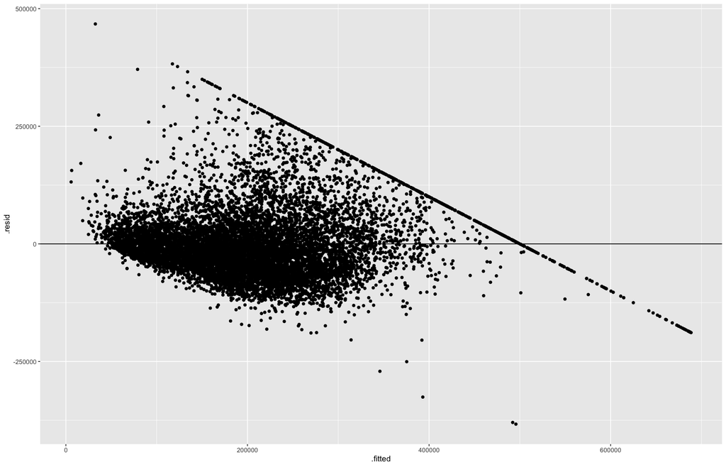

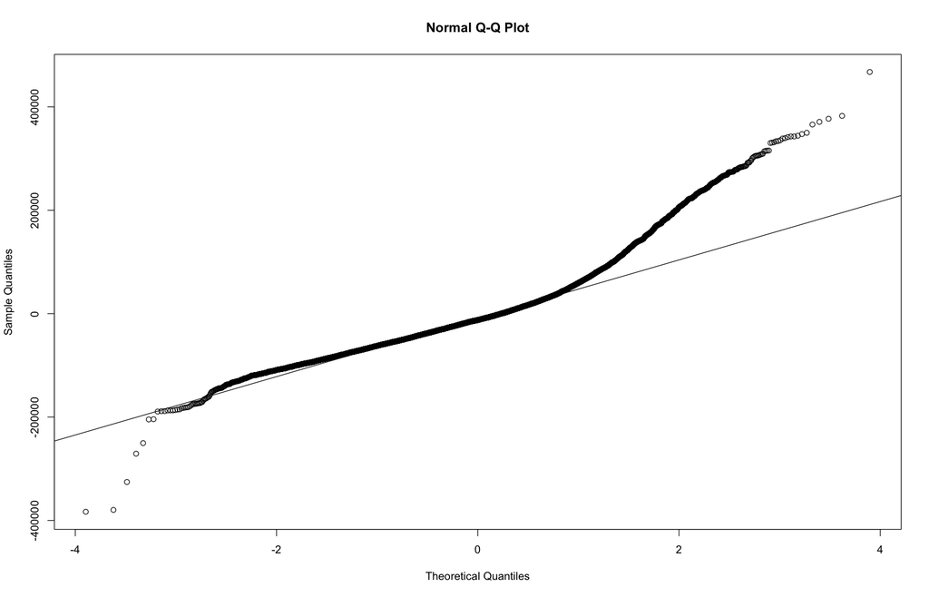

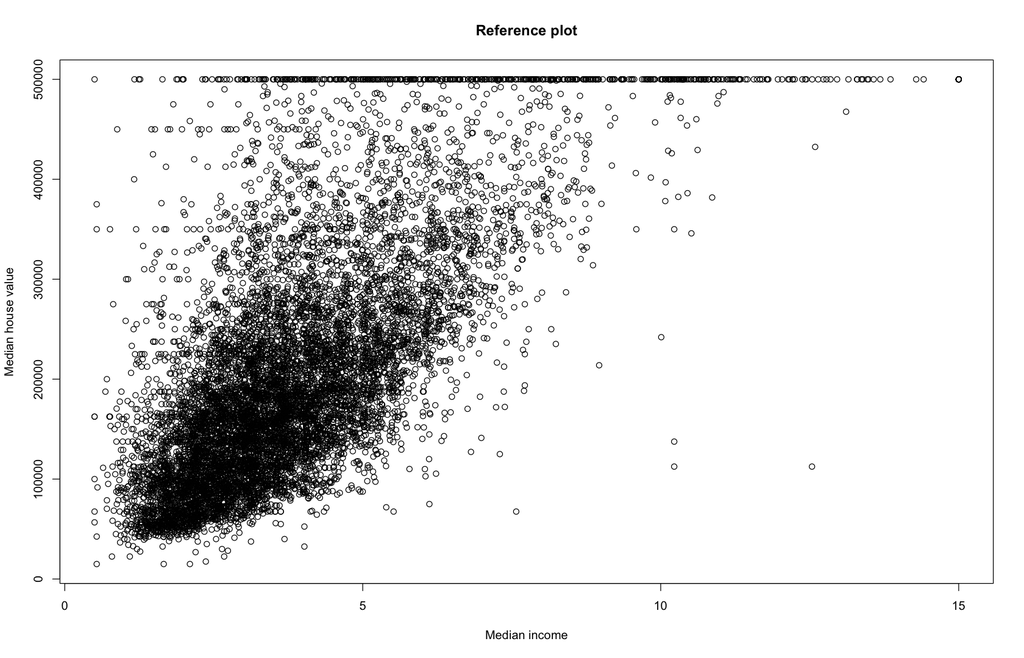

```r
ggplot(fit_final, aes(x = .fitted, y = .resid)) +
  geom_point() +
  geom_hline(yintercept = 0)

qqplot_resid <- qqnorm(resid(fit_final))
qqline(resid(fit_final))

plot(section2$median_income, section2$median_house_value, main ="Reference plot", xlab = "Median income", ylab = "Median house value")
```

There is an obvious diagonal line in our residual plot because that is upper limit of our response variable. There are no data points with a `medin_house_value` beyond 500000 (shown above in the reference scatter plot). However, we can see our residual plot has heteroscedasticity. The qqplot also does not suggest that our residuals are normally distributed. As a result, we will fit another model using log(y) as the response variable.

### Final Inference Model with log(Y)

```r
fit_final_log <- lm(log(median_house_value) ~
housing_median_age
+ population
+ median_income
+ bedrooms_per_household
+ ocean_proximity
+ population_per_household, data = section2)

tidy(fit_final_log) %>% mutate_if(is.numeric, round, digits = 3)
```

A tibble: 10 × 5

| term <chr> | estimate <dbl> | std.error <dbl> | statistic <dbl> | p.value <dbl> |
| --- | --- | --- | --- | --- |
| (Intercept) | 11.427 | 0.019 | 587.593 | 0.000 |
| housing_median_age | 0.002 | 0.000 | 7.113 | 0.000 |
| population | 0.000 | 0.000 | 3.661 | 0.000 |
| median_income | 0.173 | 0.002 | 88.359 | 0.000 |
| bedrooms_per_household | 0.062 | 0.008 | 7.740 | 0.000 |
| ocean_proximityINLAND | -0.511 | 0.009 | -58.579 | 0.000 |
| ocean_proximityISLAND | 0.691 | 0.205 | 3.368 | 0.001 |
| ocean_proximityNEAR BAY | 0.023 | 0.012 | 1.942 | 0.052 |
| ocean_proximityNEAR OCEAN | 0.033 | 0.011 | 2.989 | 0.003 |
| population_per_household | -0.001 | 0.000 | -5.739 | 0.000 |

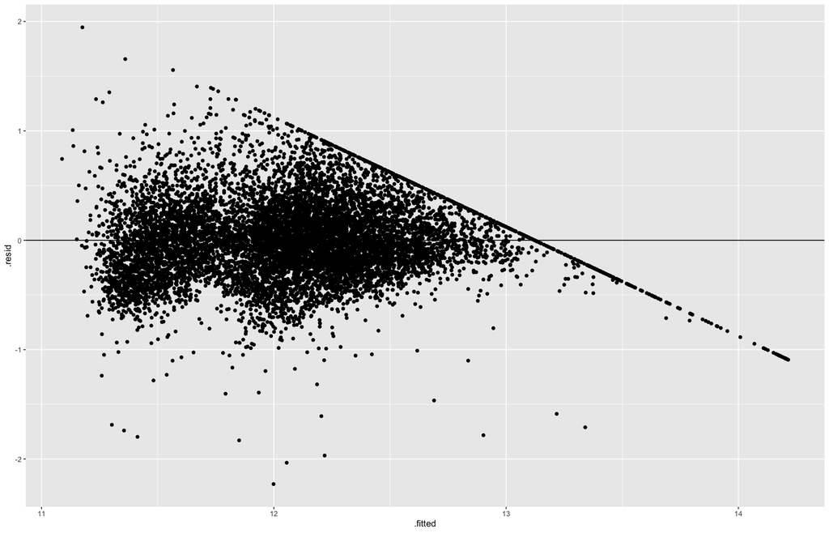

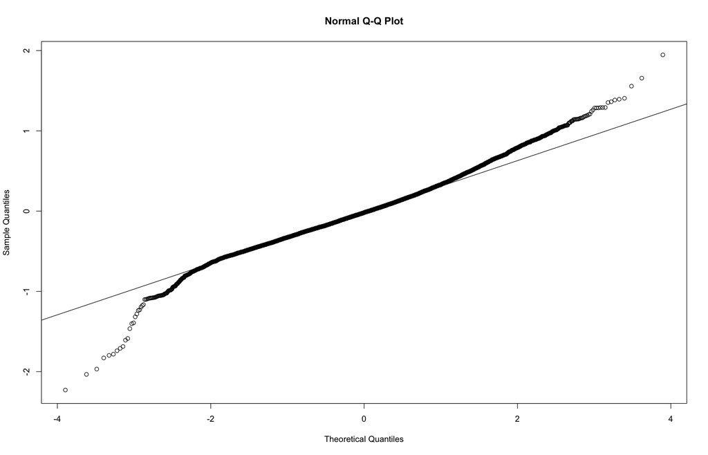

```r
ggplot(fit_final_log, aes(x = .fitted, y = .resid)) +
  geom_point() +
  geom_hline(yintercept = 0)

qqnorm(resid(fit_final_log))
qqline(resid(fit_final_log))
```

### Model performance

```r
summary(fit_final_log)$r.squared
```

0.616874419274384

Because the goal of our project is to draw inference not prediction, we will not be conducting any predictions on new data. With an $R^2$ value of around 0.62, around 62% of the variance for `median_house_value` is explained by our model. Our group thinks that this number is acceptable because there might be a lot of other factors that affect the housing market and the relationships might not be captured by a linear model.

For a linear model, we are satisfied with the result we got.

## Conclusion

This means that other than ocean_proximity == inland and population_per_household, all other variables holds a positive relationship to log(Y), which essentially means a positive relationship to Y.

This project helped us gain a deeper understanding of the housing market, and we think that the process of doing this project pushed us towards a brighter direction towards our future.